# RJ_Website

Alison Turner

2023-29-06

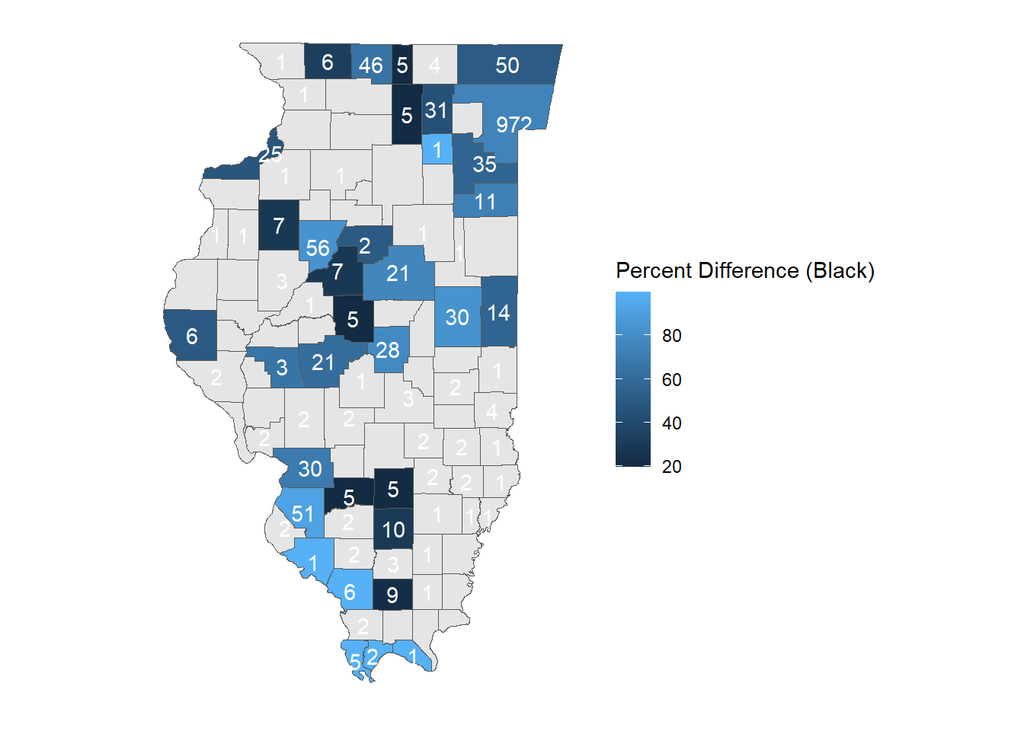

In Illinois today, there are 1610 people who were taken into custody before the age of 26 serving sentences of life and de facto life in state prisons. De facto life is defined by the United States Sentencing Commission as termed sentences longer than 40 years. These people represent about 6 percent (29245) of Illinois’s prison population.

Each case and person is unique, and few statements can describe all individuals serving extreme sentences. That said, knowing at a broad level who bears the burden of the state’s most extreme sentences helps us understand the issues, craft more nuanced policies, and build common ground for dialogue between communities, advocates, and legislators.

Here’s what we know about this group of individuals.

## Who They Are

Overwhelmingly, the people in Illinois serving life and de facto life for offenses that occurred before the age of 26 are young Black men from Cook and its neighboring counties. Figure 1 shows the distribution of sentences by race, compared with Illinois demographics.

About 87 percent of youth life and de facto life sentences are for homicide-related offenses.

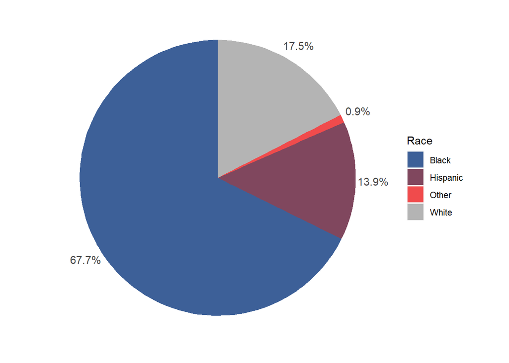

[figure not shown]

## When They Enter

More than half (56) of the people currently serving youth life or de facto life received their sentences before 2004.

Figure 2 shows the distribution of ages when individuals were taken into custody.

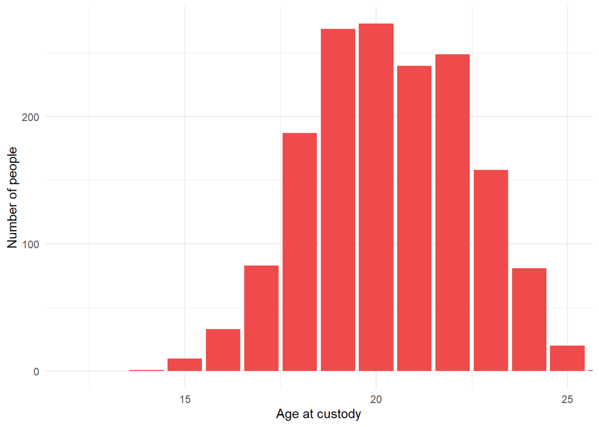

Figure 3 shows the distribution of sentence year for the current population of serving individuals.

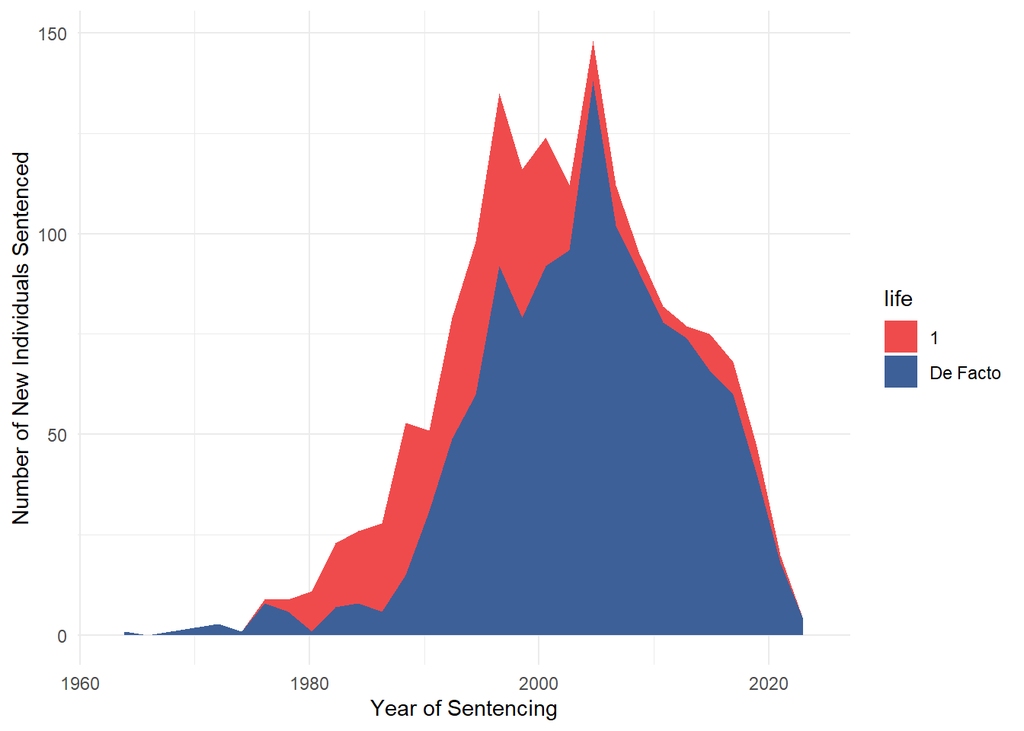

Figure 4. Distribution of Youth Life and De Facto Life Sentences by Length and Type

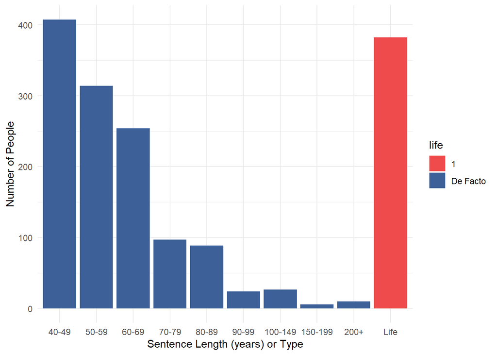